# Project 3 - Obianuju Igbokwe

### Deliverable 3 - Create the ensemble model.

#### Create a decision tree model DecisionTreeClassifier with Gini index algorithm as the criterion .

Decision tree algorithm is chosen because it fits both categorical and continuous numeric variables. It is also used for building both classification and regression models.  
Gini index criterion is used because:

1. It works for outcomes that are successes or failures.
2. It is only used for binary splits.
3. CART (Classification and Regression Tree) uses Gini to create binary splits.

```python
dTree = DecisionTreeClassifier(criterion="gini", random_state= 7)
dTree.fit(X_train, y_train)
```

```
DecisionTreeClassifier(class_weight=None, criterion='gini', max_depth=None,
                       max_features=None, max_leaf_nodes=None,
                       min_impurity_decrease=0.0, min_impurity_split=None,
                       min_samples_leaf=1, min_samples_split=2,
                       min_weight_fraction_leaf=0.0, presort=False,
                       random_state=7, splitter='best')
```

```python
print('The performance of our model is below:')
print(dTree.score(X_train, y_train))
print(dTree.score(X_test, y_test))
```

```
The performance of our model is below:
1.0
0.8752580359775878
```

```python
# Pruning the model
print("Our model is overfitting on the test data as seen in the drop in test accuracy.")
print("Prune the model by reducing  the max_depth to reduce the noise in the model.")
#Reducing the maximum depth reduces noise.
dTree_pruned = DecisionTreeClassifier(criterion="gini", max_depth= 5, min_samples_leaf=5, random_state= 7)
dTree_pruned.fit(X_train, y_train)

print("")
print('The performance of the pruned model is below:')
print(f'Training accuracy: {dTree_pruned.score(X_train, y_train)}')
print(f'Testing accuracy: {dTree_pruned.score(X_test, y_test)}')
```

```
Our model is overfitting on the test data as seen in the drop in test accuracy.
Prune the model by reducing  the max_depth to reduce the noise in the model.
```

```
DecisionTreeClassifier(class_weight=None, criterion='gini', max_depth=5,
                       max_features=None, max_leaf_nodes=None,
                       min_impurity_decrease=0.0, min_impurity_split=None,
                       min_samples_leaf=5, min_samples_split=2,
                       min_weight_fraction_leaf=0.0, presort=False,
                       random_state=7, splitter='best')
```

```
The performance of the pruned model is below:
Training accuracy: 0.9037507504660789
Testing accuracy: 0.9028310232969625
```

[figure not shown]

```python
#Visualise the pruned tree

train_char_label = ['No', 'Yes']
Term_Dep_File = open('term_dep.dot','w')
dot_data = tree.export_graphviz(dTree_pruned, out_file=Term_Dep_File, feature_names = list(X_train), class_names = list(train_char_label))
Term_Dep_File.close()


retCode = system("dot -Tpng term_dep.dot -o term_dep.png")
if(retCode>0):
    print("system command returning error: "+str(retCode))
else:
    display(Image("term_dep.png"))
```

```
Confusion Matrix
```

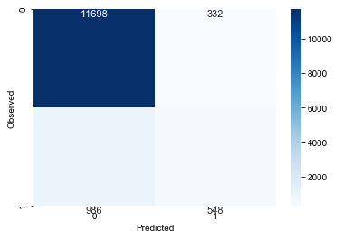

```
None
```

```python
# Confusion Matrix for the pruned model

from sklearn import metrics
# Predict outcomes from X
y_predict_test = dTree_pruned.predict(X_test)
y_predict_train = dTree_pruned.predict(X_train)

# Function to get confusion matrix
def draw_cm(actual, predicted):
    cm = metrics.confusion_matrix(actual, predicted)
    akws = {'size':11, "ha": 'center',"va": 'top'}
    sns.heatmap(cm, cmap='Blues', annot=True,  annot_kws= akws,
                fmt= 'd', xticklabels = [0,1] , yticklabels = [0,1])
    plt.ylabel('Observed')
    plt.xlabel('Predicted')
    sns.set(font_scale=1.4)
    plt.figure(figsize=(10, 7))
    plt.show()

print('Confusion Matrix')
print(draw_cm(y_test,y_predict_test))
```

```python
prec = precision_score(y_test, y_predict_test)
rec = recall_score(y_test, y_predict_test)
f1 = f1_score(y_test, y_predict_test)
rocAuc = roc_auc_score(y_test, y_predict_test)
newline = '\n'
print('The performance of the pruned model is below:')
print(f'Training accuracy: {dTree_pruned.score(X_train, y_train)}')
print(f'Testing accuracy: {dTree_pruned.score(X_test, y_test)}')
print(f"Precision: {prec}\
{newline}Recall: {rec}\
{newline}F1 Score: {f1}\
{newline}Roc Auc Score: {rocAuc}")

print("The precision and recall on the model are rather low as compared to the training and testing accuracy.")
```

```
The performance of the pruned model is below:
Training accuracy: 0.9037507504660789
Testing accuracy: 0.9028310232969625
Precision: 0.6227272727272727
Recall: 0.35723598435462844
F1 Score: 0.4540182270091135
Roc Auc Score: 0.6648191559345877
The precision and recall on the model are rather low as compared to the training and testing accuracy.
```

```python
#Store the accuracy results for each model in a dataframe for final comparison
acc_dTree_pruned = accuracy_score(y_test, y_predict_test)


resultsDf = pd.DataFrame({'Method':['Decision Tree'], 'Accuracy': acc_dTree_pruned})
resultsDf = resultsDf[['Method', 'Accuracy']]
resultsDf
```

|  | Method | Accuracy |
| --- | --- | --- |
| 0 | Decision Tree | 0.902831 |

#### Advantages of Decision Tree Algorithm

1. Compared to other algorithms, a decision tree requires less effort for data preparation during preprocessing.
2. Decision trees do not require normalization of data.
3. Decision trees do not require scaling of data.
4. Decision trees are easy to explain to stakeholders, they follow the approach that humans generally take in making decisions.

#### Disadvantages of Decision Tree Algorithm

1. Decision trees have a high probability of overfitting.
2. A small change in the data can cause a large change in the structure of the decision tree, causing instability.
3. Decision trees are expensive in terms of complexity and training time.
4. It generally gives lesser prediction accuracy as compared to other machine learning algorithms.

#### Bagging Classifier Algorithm application to the same data

```python
from sklearn.ensemble import BaggingClassifier

bAlgo = BaggingClassifier(n_estimators=50, max_samples= 0.7, oob_score=True, bootstrap=True, random_state=24)
bAlgo = bAlgo.fit(X_train, y_train)
```

```python
pred_bAlgo = bAlgo.predict(X_test)
acc_bAlgo = accuracy_score(y_test, pred_bAlgo)
```

```python
temp_resultsDf = pd.DataFrame({'Method':['Bagging'], 'Accuracy': acc_bAlgo})
resultsDf = pd.concat([resultsDf, temp_resultsDf])
resultsDf = resultsDf[['Method', 'Accuracy']]
resultsDf
```

|  | Method | Accuracy |
| --- | --- | --- |
| 0 | Decision Tree | 0.902831 |
| 0 | Bagging | 0.902462 |

The result shows approximately the same accuracy for Decision Tree and Bagging

#### AdaBoost Classifier Algorithm application to the same data

```python
from sklearn.ensemble import AdaBoostClassifier

adAlgo = AdaBoostClassifier(n_estimators=100, learning_rate=0.1, random_state=24)
adAlgo = adAlgo.fit(X_train, y_train)
```

```python
pred_adAlgo = adAlgo.predict(X_test)
acc_adAlgo = accuracy_score(y_test, pred_adAlgo)
```

```python
temp_resultsDf = pd.DataFrame({'Method':['AdaBoost'], 'Accuracy': acc_adAlgo})
resultsDf = pd.concat([resultsDf, temp_resultsDf])
resultsDf = resultsDf[['Method', 'Accuracy']]
resultsDf
```

|  | Method | Accuracy |
| --- | --- | --- |
| 0 | Decision Tree | 0.902831 |
| 0 | Bagging | 0.902462 |
| 0 | AdaBoost | 0.895753 |

#### GradientBoost Classifier Algorithm application to the same data

```python
from sklearn.ensemble import GradientBoostingClassifier
gbAlgo = GradientBoostingClassifier(n_estimators=50, learning_rate=0.1, random_state=24)
gbAlgo = gbAlgo.fit(X_train, y_train)
```

```python
pred_gbAlgo = gbAlgo.predict(X_test)
acc_gbAlgo = accuracy_score(y_test, pred_gbAlgo)
```

```python
temp_resultsDf = pd.DataFrame({'Method':['GradientBoost'], 'Accuracy': acc_gbAlgo})
resultsDf = pd.concat([resultsDf, temp_resultsDf])
resultsDf = resultsDf[['Method', 'Accuracy']]
resultsDf
```

|  | Method | Accuracy |
| --- | --- | --- |
| 0 | Decision Tree | 0.902831 |
| 0 | Bagging | 0.902462 |
| 0 | AdaBoost | 0.895753 |
| 0 | GradientBoost | 0.907328 |

#### Random Forest Classifier Algorithm application to the same data

```python
from sklearn.ensemble import RandomForestClassifier

rfAlgo = RandomForestClassifier(n_estimators=50)
rfAlgo = rfAlgo.fit(X_train, y_train)
```

```python
pred_rfAlgo = rfAlgo.predict(X_test)
acc_rfAlgo = accuracy_score(y_test, pred_rfAlgo)
```

```python
temp_resultsDf = pd.DataFrame({'Method':['Random Forest'], 'Accuracy': acc_rfAlgo})
resultsDf = pd.concat([resultsDf, temp_resultsDf])
resultsDf = resultsDf[['Method', 'Accuracy']]
resultsDf
```

|  | Method | Accuracy |
| --- | --- | --- |
| 0 | Decision Tree | 0.902831 |
| 0 | Bagging | 0.902462 |
| 0 | AdaBoost | 0.895753 |
| 0 | GradientBoost | 0.907328 |
| 0 | Random Forest | 0.908360 |

#### Conclusion: Random Forest algorithm gave the best accuracy results on test predictions.